# Report Exercise: re_airquality

Patrick Bigler

2023-04-10

Course: Applied Geo-Data Science at the University of Bern (Institute of Geography)

Supervisor: Prof. Dr. Benjamin Stocker

Adviser: Dr. Koen Hufkens, Pepa Aran, Pascal Schneider

Further information: https://geco-bern.github.io/agds/

Do you have questions about the workflow? Contact the Author:

Author: Bigler Patrick (patrick.bigler1@students.unibe.ch)

Matriculation number: 20-100-178

Reference: Report Exercise 3 (Chapter 4)

# 1 Introduction

## 1.1 Objectives

Visualizations are a proper way to communicate the results. The variety of diagrams, colors, and shapes is almost limitless. However, not all of them are always equally suitable. It is essential to create the right graphic to transport the message. With a realistic problem, the following goals should be achieved:

- Appropriate choice of visualizations for different data types and different aspects of the data
- Grammar of graphics (ggplot2)
- The proper use of colors in visualization

## 1.2 Theory

Air quality depends on factors such as particulate matter, nitrogen dioxide $(NO_2)$ or ozone $(O_3)$. Ozone is not a health hazard per se, but a high concentration over a longer period of time can affect health (Brönnimann 2013, 23). But what are high concentrations? The limit value for hourly mean ozone concentrations set in the “Swiss Air Pollution Control Act” is $120\: \frac{\mu g}{m^3}$ (Brönnimann 2013, 23). However, this unit depends on the air pressure, which decreases with altitude. The volume mixing ratio with the unit parts per billion is more suitable, which is about 60 ppb (Brönnimann 2013, 26). Here, we use this value.

Ozone is a molecule consisting of three oxygen atoms and has various physical (absorption of UV and IR radiation) and chemical (high reactivity) properties. Ozone emerges due to a two-phase chemical reaction (Brönnimann 2013, 75):

1. $NO_2 + h\nu \left(\lambda < 420 nm \right) \rightleftharpoons NO + O$
2. $NO + O_3 \rightleftharpoons NO_2 + O_2$

The reaction equations show that UV radiation, oxygen, and nitrogen dioxide are needed for the formation of ozone. The first two are available in almost unlimited quantities. Further, many chemical reactions are temperature dependent. This is also true for ozone. The higher the temperature, the more the balance of the reaction shifts towards ozone production, and the concentration increases (Brönnimann 2013, 95).

In summary, the ozone concentration probably depends on temperature (shift of the balance), solar radiation (mostly UV radiation), and the concentration of nitrogen dioxide (which depends among other things on wind). With these considerations, a data set on air quality can be studied with a focus on ozone.

## 1.3 Hypothesis

This exercise is supposed to answer the following research question:

*“The tropospheric ozone concentration depends on temperature, solar radiation, and wind.”*

# 2 Methods

## 2.1 Unit transformation

Using the SI unit system is strongly recommended because it simplifies the reproducibility, interpretation, and discussion of the data. It follows the formulas to transform the units into the SI-unit system.

- The following formula was used for temperature:
  $$\frac{x \left[°Fahrenheit \right]- 32}{1.8}
  +273.15 \Longleftrightarrow x\left[Kelvin \right]$$
- The following formula was used for wind:
  $$1 \left[\frac{mile}{hour} \right]
  \Longleftrightarrow 0.44704
  \left[\frac{meter}{second}\right]$$
- The following formula was used for radiant exposure
  $$1 \left[ Langley \right] \Longleftrightarrow
  41840 \left[ \frac{Joule}{m^2}\right]$$

## 2.2 R: Evaluation of the data

The open-source program R-Studio (Version 2022.12.0+353) was used for all studies. The data handling in this program is done using the R language. We utilize the R-package “Tidyverse” and other packages to process the data effectively.

# 3 Programming and data evaluation

## 3.1 Packages

The following code chunk contains all packages we need. Important is the package “conflicted”. It enables us to chose if different functions have the same call but do not make the same thing (a function in a certain package can have the same name as a function from another package).

```r
# Load all packages
source("../../R/general/packages.R")
```

## 3.2 Read the file

First, we get the data and save it in our directory. But we must do this only once. If the file exists, then we can read it directly. That is why we implemented an if-else statement.

```r
# We want know, if a certain file already exists
name.of.file <- "../../data/re_airquality/airquality.csv"

# If do not exists such a file, create it!
if (!file.exists(name.of.file)){
  # Read the data
  airquality.raw <- datasets::airquality

  # Write a CSV file in the respiratory to save the data
  write_csv(airquality.raw, "../../data/re_airquality/airquality.csv")

  # Read the file
  airquality <- read_csv("../../data/re_airquality/airquality.csv")

  # If exists such a file, read it only!
  }else{airquality <- read_csv("../../data/re_airquality/airquality.csv")}
```

## 3.3 Data Overview

The data is an example data frame from the “datasets” package. The database is a secondary source. We must familiarize ourselves with its contents, variables, and units. For that, we can use R to gather all the information.

### 3.3.1 Missing values

With help() we see that the variables do not have SI units. With sapply() we can check the class of the columns. With apply() we can see that there are NA. We call a function to visualize the NA because we must know where they are.

```r
# Ask for details (units, source and references)
help("airquality")

# Check the class of each column
as.data.frame(sapply(airquality, class))
```

```
##         sapply(airquality, class)
## Ozone                     numeric
## Solar.R                   numeric
## Wind                      numeric
## Temp                      numeric
## Month                     numeric
## Day                       numeric
```

```r
# Take a overview and main statistic parameters
summary(airquality)
```

```
##      Ozone           Solar.R           Wind             Temp
##  Min.   :  1.00   Min.   :  7.0   Min.   : 1.700   Min.   :56.00
##  1st Qu.: 18.00   1st Qu.:115.8   1st Qu.: 7.400   1st Qu.:72.00
##  Median : 31.50   Median :205.0   Median : 9.700   Median :79.00
##  Mean   : 42.13   Mean   :185.9   Mean   : 9.958   Mean   :77.88
##  3rd Qu.: 63.25   3rd Qu.:258.8   3rd Qu.:11.500   3rd Qu.:85.00
##  Max.   :168.00   Max.   :334.0   Max.   :20.700   Max.   :97.00
##  NA's   :37       NA's   :7
##      Month            Day
##  Min.   :5.000   Min.   : 1.0
##  1st Qu.:6.000   1st Qu.: 8.0
##  Median :7.000   Median :16.0
##  Mean   :6.993   Mean   :15.8
##  3rd Qu.:8.000   3rd Qu.:23.0
##  Max.   :9.000   Max.   :31.0
##
```

```r
# Check wheater there are any missing values (We try with only the first six rows)
head(apply(airquality,2, function(x) is.na(x)))
```

```
##      Ozone Solar.R  Wind  Temp Month   Day
## [1,] FALSE   FALSE FALSE FALSE FALSE FALSE
## [2,] FALSE   FALSE FALSE FALSE FALSE FALSE
## [3,] FALSE   FALSE FALSE FALSE FALSE FALSE
## [4,] FALSE   FALSE FALSE FALSE FALSE FALSE
## [5,]  TRUE    TRUE FALSE FALSE FALSE FALSE
## [6,] FALSE    TRUE FALSE FALSE FALSE FALSE
```

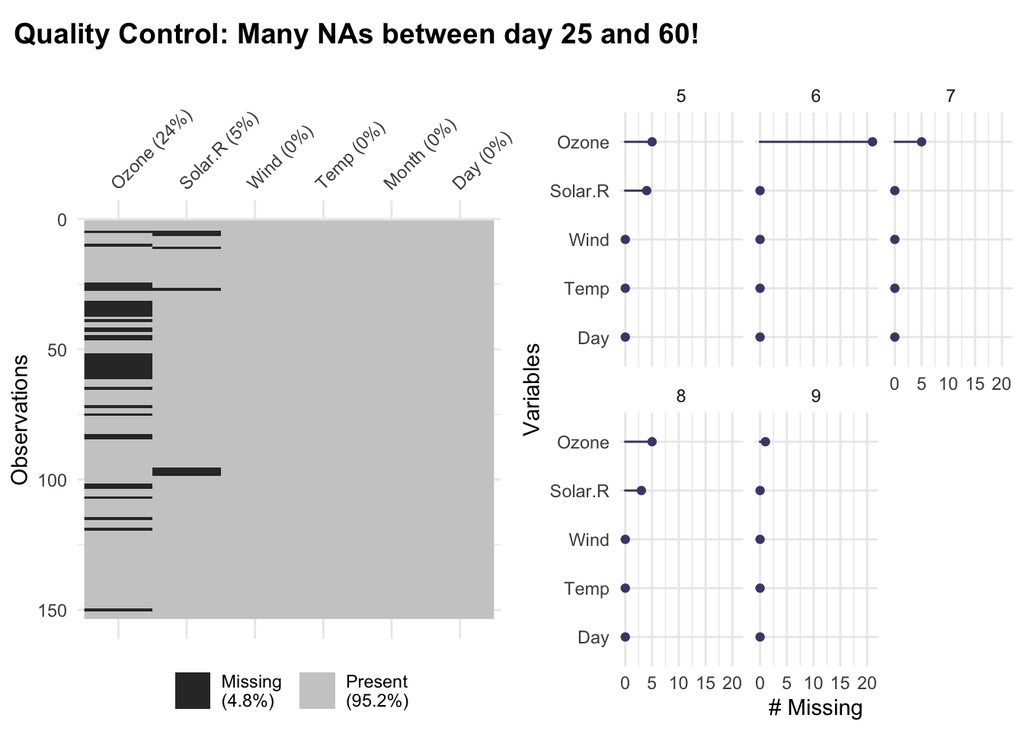

```r
# Load the function
source("../../R/general/function.visualize.na.values.R")

# Function call to vis. the NA
visualize.na.values(airquality, c("Many NAs between day 25 and 60!"))
```

### 3.3.2 Sources

The data frame shows different variables at different times. The measurement series starts on May 1, 1973, and lasts until September 30, 1973. Each variable has a value for each day (it could be “NA” as well). We distinguish the variable according to the source.

Data for ozone were collected from the New York State Department of Conservation:

- Ozone [ppb] represents the average concentration between 1 p.m. and 3 p.m. at Roosevelt Island, NYC.

The meteorological data were collected from the US National Weather Service:

- Wind [mph] is calculated as the average wind speed at 7 a.m. and 10 a.m. at La Guardia Airport, NYC.
- Temperature [degrees Fahrenheit] is the maximum daily temperature at La Guardia Airport, NYC.
- Solar. R [Langley] averages in the frequency band 4000–7700 Angstroms (wavelength: 400–770 nanometers) from 8 a.m. to noon in Central Park, NYC.

We want to use SI-units. That is why we make a function call and change units into the SI system.

```r
# Load the function
source("../../R/re_airquality/function.unit.converter.R")

# Function call
airquality_mutated <- unit.converter(airquality)
```

## 3.4 Statistics and its paramaters

Now that all units have been converted to SI units, the question of position, dispersion, and distribution parameters arises. For the ozone concentration, the median is a good position parameter because it is robust against outliers. This is important because a short-term elevated ozone concentration will probably not endanger health. If we use the mean as a position parameter, we could lose the overall picture due to a big one-time outlier. If the median has been used as a position parameter, the IQR should be used as a dispersion parameter. This will allow us to estimate how high the data scatter is. But we are also interested in the maximal values. An environment with a very high ozone concentration can be toxic (even for short-time exposure).

```r
# Calculate the main statistic parameters.
knitr::kable(airquality_mutated|>
  group_by(Group)|>
  summarise(Frequncy = length(na.omit(Ozone)),
            Median = round(median(Ozone, na.rm = TRUE), digits = 0),
            IQR = round(IQR(Ozone, na.rm = TRUE), digits = 0),
            Q.25 = round(quantile(Ozone, 0.25, na.rm = TRUE), digits = 0),
            Q.75 = round(quantile(Ozone, 0.75, na.rm = TRUE), digits = 0),
            Max = round(max(Ozone, na.rm = TRUE), digits = 0),
            Min = round(min(Ozone, na.rm = TRUE), digits = 0),
            Mean = round(mean(Ozone, na.rm = TRUE),digits = 0),
            STD = round(sd(Ozone, na.rm = TRUE), digits = 0),
            Max = round(max(Ozone, na.rm = TRUE), digits = 0),
            Min = round(min(Ozone, na.rm = TRUE), digits = 0),
            Span = round(max(Ozone, na.rm = TRUE), digits = 0) -
                   round(min(Ozone, na.rm = TRUE), digits = 0)),
            caption = "Table 1: Overview of main statistical parameters (unit [ppb])",
            align = c("l", rep("c", 11)), format = "html")|>
  kableExtra::kable_classic()
```

Table 1: Overview of main statistical parameters (unit [ppb])

| Group | Frequncy | Median | IQR | Q.25 | Q.75 | Max | Min | Mean | STD | Span |
| --- | --- | --- | --- | --- | --- | --- | --- | --- | --- | --- |
| May | 26 | 18 | 20 | 11 | 32 | 115 | 1 | 24 | 22 | 114 |
| Jun | 9 | 23 | 17 | 20 | 37 | 71 | 12 | 29 | 18 | 59 |
| Jul | 26 | 60 | 44 | 36 | 80 | 135 | 7 | 59 | 32 | 128 |
| Aug | 26 | 52 | 54 | 29 | 82 | 168 | 9 | 60 | 40 | 159 |
| Sept | 29 | 23 | 20 | 16 | 36 | 96 | 7 | 31 | 24 | 89 |

### 3.4.1 Box-Whisker Plot

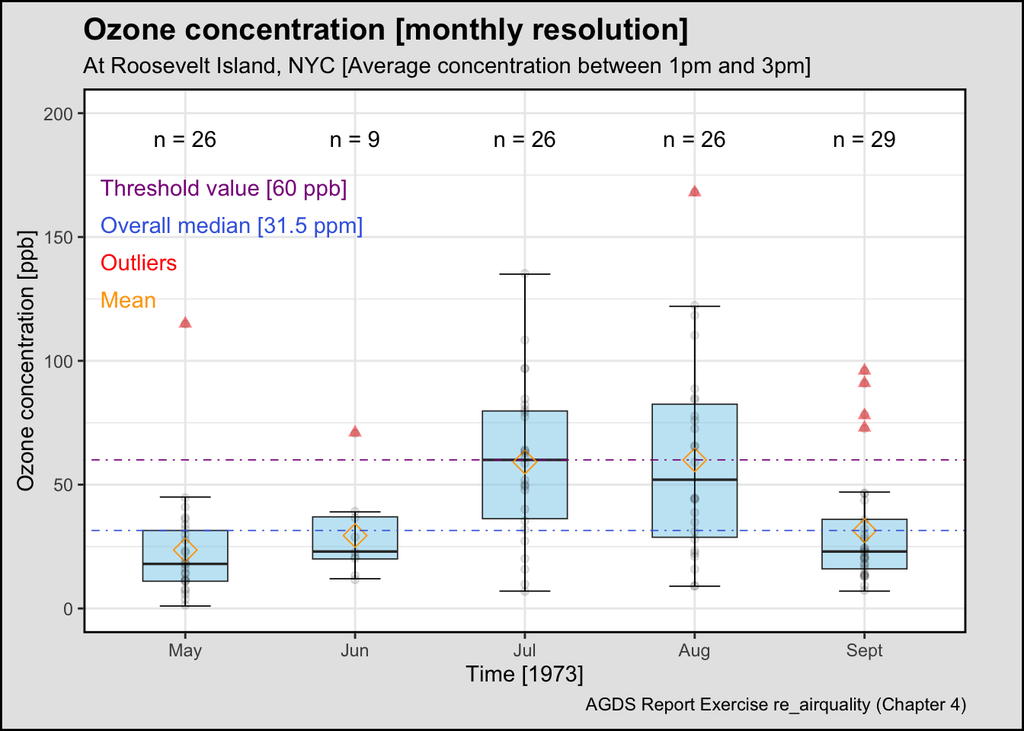

```r
# Load the function
source("../../R/re_airquality/function.boxplot.R")

# Function call
airquality.boxplot(airquality_mutated)
```

### 3.4.2 Density-Plot

The density plot shows us that the data has a large span and a positive skewness. But the core of the data (the area with highest density) has an acceptable span (which is basically the IQR). The graphs also show us that the density for the months of May, June, and September is bimodal which means there are outliers (we already see that in the box-whisker plot). July and August are monomodal but have a large span. This we could see in the box-whisker plot (large boxes) as well.

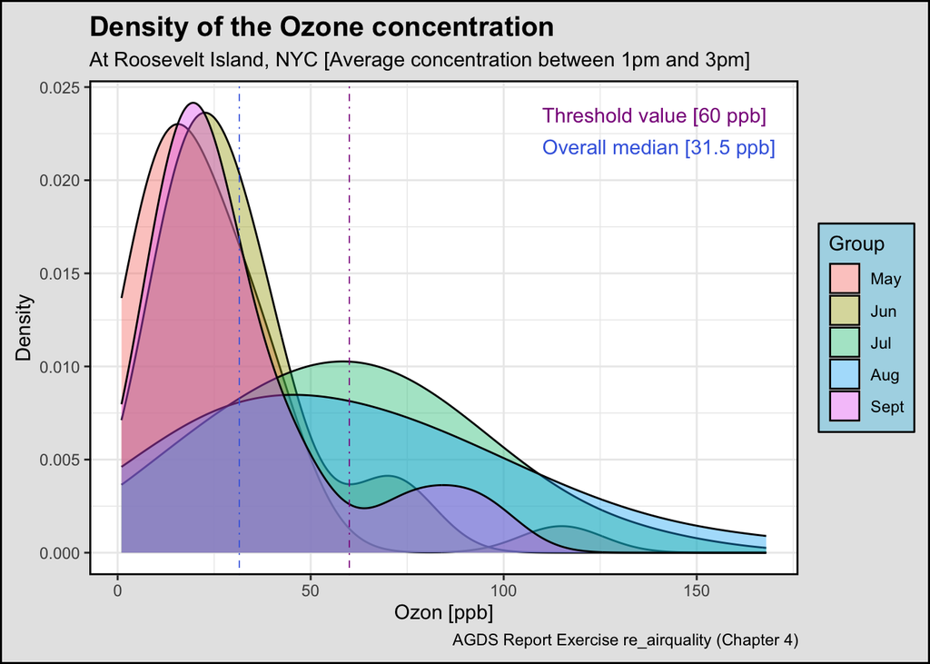

```r
# Load the function
source("../../R/re_airquality/function.density.plot.R")

# Function call
density.airquality(airquality_mutated)
```

### 3.4.3 Empirical Cumulative Density Function

In this plot we can see that 73% of the values are smaller than the threshold value. It follows that approximately 27% of the days has a exceed of the threshold value.

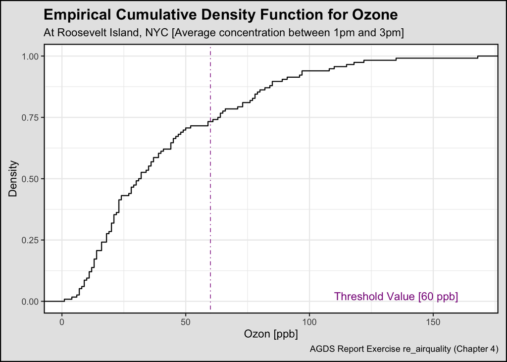

```r
# Load the function
source("../../R/re_airquality/function.empirical.R")

# Function call
emp.dist.airquality(airquality_mutated)
```

### 3.4.4 Bar Plot and the distribution of the missing values in a timeline

We detected many missing values. For a stringent analysis, we need to know which values are missing and where they are. Is there a systematic error in the instrument’s sensitivity? Or simply forgot someone to write down the measurement? For that, we use a bar plot that replaces all NA values with -1. Now we can easily see which values are missing. We are missing a lot of values for June. Creating new values through linear interpolation is not an option because there are (1) too many NAs and (2) the gap between the values is too big. We would only falsify our analysis. But all the other missing values are not problematic, and we can proceed straight forward.

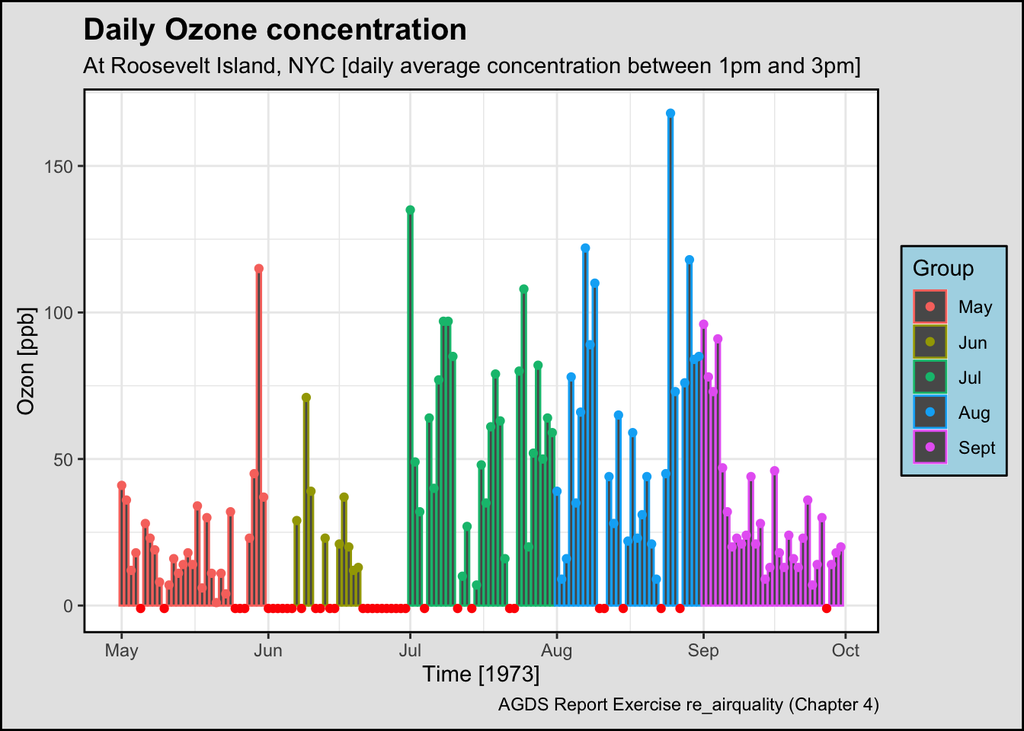

```r
# Load the function
source("../../R/re_airquality/function.na.identifier.R")

# Function call
na.identifier(airquality_mutated )
```

### 3.4.5 Correlation

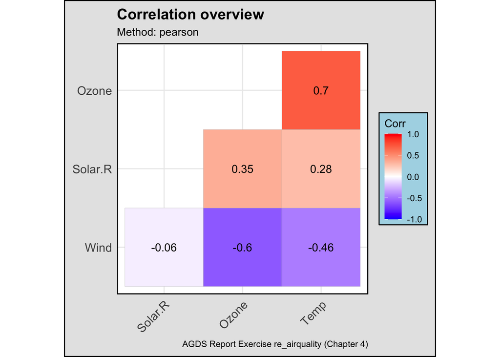

```r
source("../../R/re_airquality/function.correlation.plot.R")

correlation.plot(airquality_mutated, c("pearson"))
```

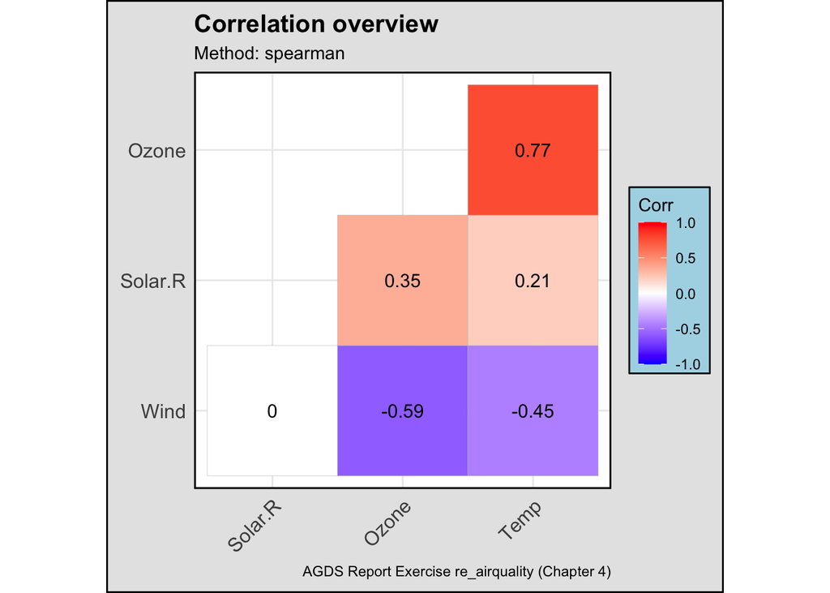

```r
correlation.plot(airquality_mutated, c("spearman"))
```

We have seen that there is a negative correlation between temperature and wind. From a meteorological point of view, this makes sense. That is why we make a scatter plot where the wind has a temperature dependency. We see that higher temperatures tend to produce lower winds. We also see that the lower the wind, the higher the ozone concentration.

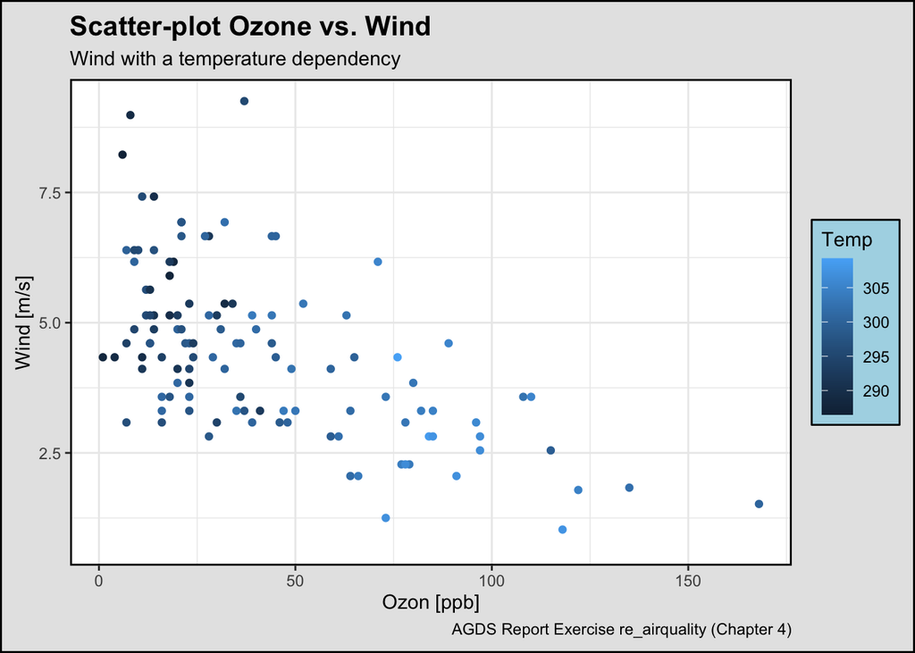

```r
# Load the function
source("../../R/re_airquality/function.air.temp.R")

# Function call
temp.and.air(airquality_mutated)
```

## 3.5 Modelling

We want to be able to predict new values (e.g. for interpolate the missing values in June). For that, we need a model. Here, we create simple linear regression models.

### 3.5.1 Linear Regression Models

The first model is ozone vs. time. The model explains only about 2.5% of the variance (RSQ = 0.024). Both the coefficient and the intercept are not significant (p-value > 0.05), and we cannot reject H0 (if the p-value is insignificant, then it indicates there is insufficient evidence in the sample to conclude that a non-zero correlation exists). We reject that model.

The second model is ozone vs. temperature. The model explains about 48% of the variance. That is not so bad, but it is far from perfect. The p-value is < 0.05 and therefore significant (even on a 99.9% level). We can reject H0. We accept the model temporarily.

The third model is ozone vs. wind. The RSQ is about 0.36. The model explains about 36% of the variance. The p-value is < 0.05, and the coefficient and the intercept are significant (even on a 99.9% level). We reject H0 and accept the model temporarily.

The last model is ozone versus solar radiation. This model is not as good as the second and third models. RSQ is only about 0.12, which explains only 12% of the variance. The p-value is < 0.05, but the intercept is only at a 99 % level of significance (actually, this is a good value, but it is, lower compared to the second and third models). We reject H0, but the model is not good. Because we have a better option, we will not use this model.

We set the code chunk to eval = FALSE because we do not want to call the models. If you interest, you can set eval = TRUE and run the code again.

```r
# Load the function
source("../../R/re_airquality/function.regression.calculater.R")

# Function call ozone vs. Date
regression.calculater(airquality_mutated, 4, 1)

# Function call ozone vs. Temperature
regression.calculater(airquality_mutated, 4, 5)

# Function call ozone vs. Wind
regression.calculater(airquality_mutated, 4, 6)

# Function call ozone vs. Solar radiation
regression.calculater(airquality_mutated, 4, 7)
```

### 3.5.2 Visualization of the models

For a better interpretation, the models can be visualized.

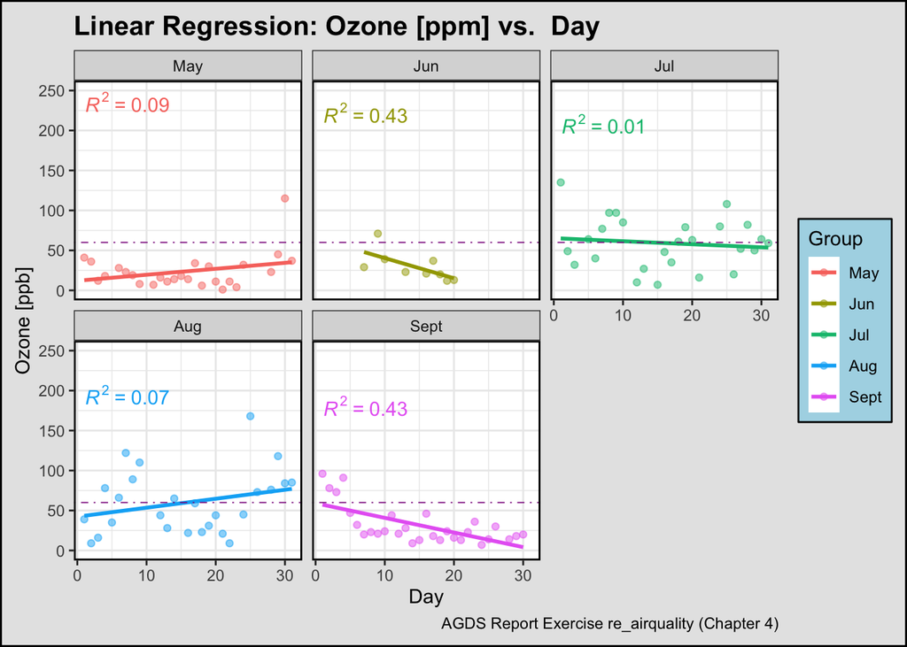

```r
# Load the function
source("../../R/re_airquality/function.regression.R")

# Function calls
airquality.regression(airquality_mutated, Day, c("Day"))
```

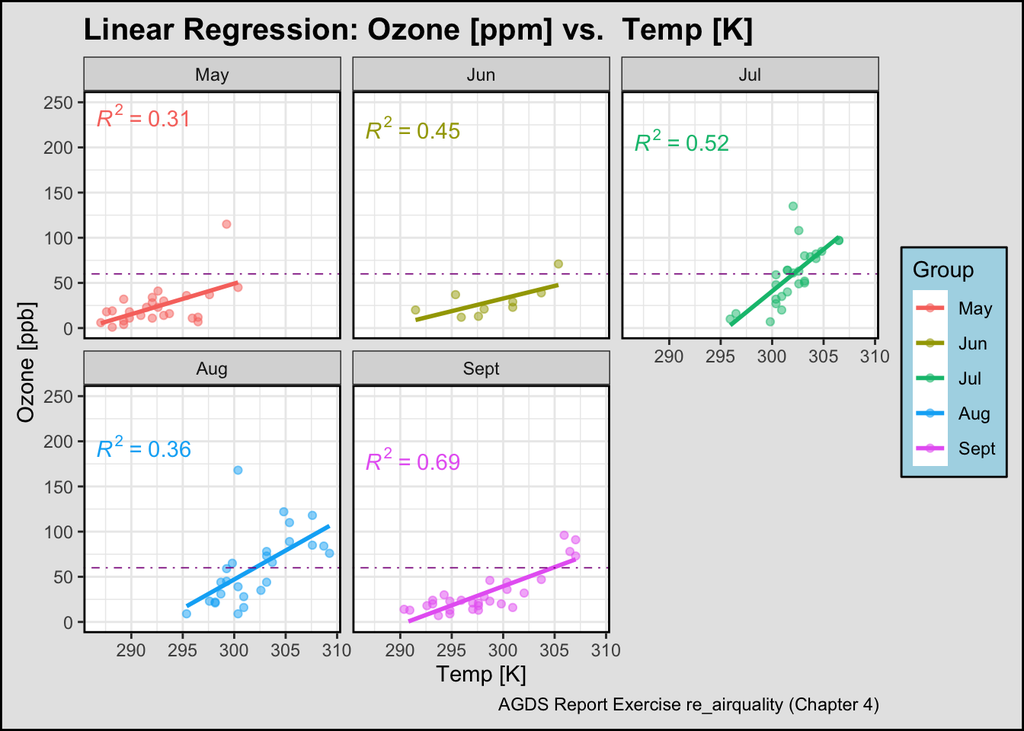

```r
airquality.regression(airquality_mutated, Temp, c("Temp [K]"))
```

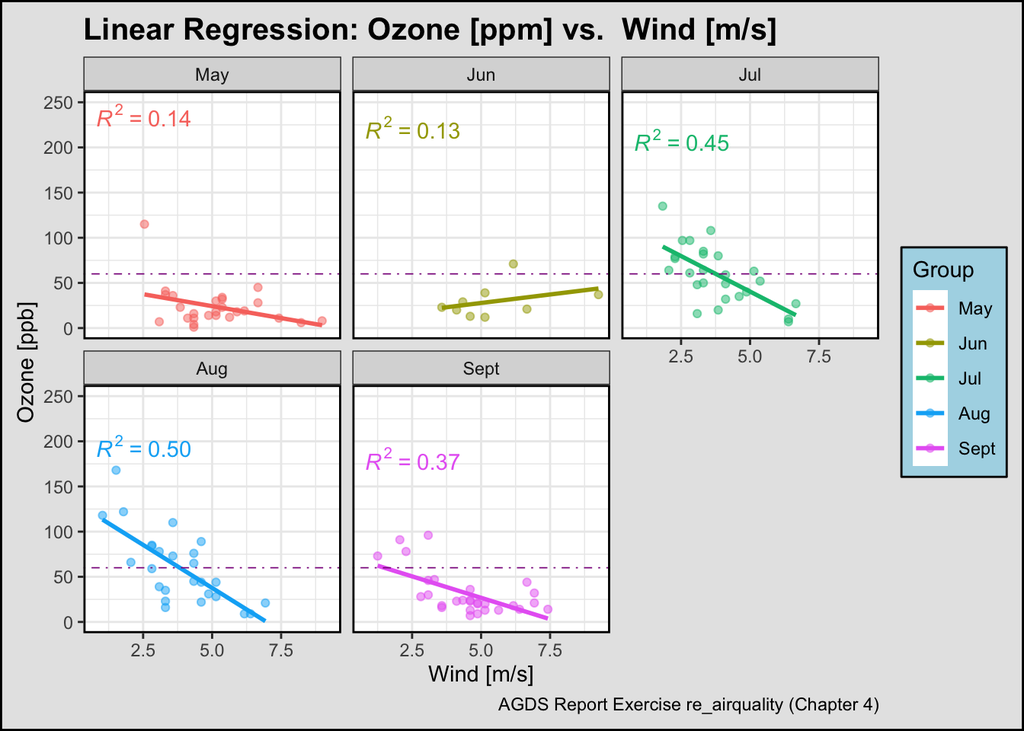

```r
airquality.regression(airquality_mutated, Wind, c("Wind [m/s]"))
```

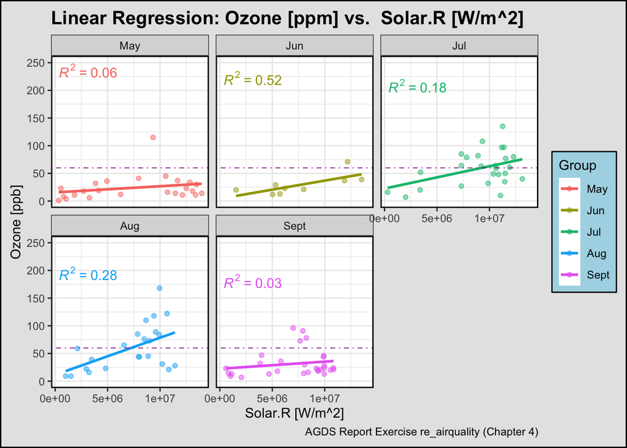

```r
airquality.regression(airquality_mutated, Solar.R, c("Solar.R [W/m^2]"))
```

# 4 Discussion

In this short analysis, we can see that ozone probably depends on temperature, wind, and solar radiation. Although the RSQ and the p-value were not bad for the second and third linear regression models, none of the models is convincing enough to use as an explanatory model. We need better approaches. One possibility would be multiple regression or machine learning approaches. However, these are not used here because they will be introduced later.

But we can take a look at this specific data set and analyze the year 1973. First, we must discuss the source. It is problematic that not all variables were measured at the same location. The ozone was measured on Roosevelt Island. It is an island on the East River in NYC. But the temperature and wind were measured at La Guardia Airfield, and the solar irradiance was measured in Central Park. The measuring stations are up to 10 kilometers apart, and this is in the middle of a city. There is no guarantee that the meteorological conditions will be the same. It would be better to collect new, up-to-date data ourselves and measure all variables in the same place.

Second, we can see that the median is lower or equal than the threshold for all months. Temperature is an important factor in ozone concentration. The same is true for wind. The ozone concentration tends to be higher if the temperature is high. In an urban space, this effect will be amplified due to heat islands. A city like NYC is predestined for such an effect.

In conclusion, we can say that the air quality is less bad than expected. But it is still poor air quality. The median is often just not exceeded. But there are still almost 27% of the days above the treshold value. There are days when the concentration is too high (true for all months). The city of New York should take measures to prevent heat islands. This could lower the temperature, which inhibits ozone production. Further, the source material should be limited. With less traffic, $NO_2$ could be lowered, which would also inhibit ozone production. Unfortunately, we could not answer our research question. We suppose it is possible if we collect more data. We are convinced (and our analysis seems to support the thesis) that we are on the right path.

(390 words)

# 5 Bibliography

Brönnimann Stefan (2013): Ozon in der Atmosphäre. Bern, Haupt Verlag. DOI: 10.480/GB2013.03